# Approaches to continuous risk-based benefit assessment

## Subgroup analyses

- Generalizing overall treatment effects is often problematic
- Subgroup analyses rarely adequately powered

## Subgroup analyses

Subgroup analyses can be divided into 4 categories (*Varadhan et al, 2013*):

- Confirmatory heterogeneity of treatment effect analysis
- Exploratory heterogeneity of treatment effect analysis
- Descriptive heterogeneity of treatment effect analysis
- *Predictive heterogeneity of treatment effect analysis*

## Predictive HTE methods

*Risk modeling*

- A multivariate regression model \(f\) that predicts the risk of an outcome \(y\) based on the predictors \(x_1\dots x_p\) is identified or developed.
- The expected outcome of a patient receiving treatment \(T\) (where \(T = 1\), when patient is treated and \(0\) otherwise) based on the linear predictor \[lp(x_1,\dots x_p) = a + \beta_1x_1 +\dots\beta_px_p\] from a previously derived risk model can be described as \[E\{y|x_1,\dots,x_p\} = f(lp + \gamma_0T+\gamma T\times lp)\]

## Risk-based HTE

*Reasoning*

- When risk is described through a combination of factors the control event rate will typically vary considerably across the trial population.
- The absolute risk difference will generally vary across risk strata even if the relative risk is the same
- When a trial population has substantial variation in outcome risk, important differences often exist in harm–benefit tradeoffs

## Individualized approaches

- Stratification approach may not provide adequate prediction of benefit
- “Jumps” at cut-offs are not realistic
- Implement a risk-based smoothing approach

## Setting

For all patients we observe covariates \(x_1,\dots,x_8\), of which \(4\) are continuous and \(4\) are binary. More specifically,

\[x_1,\dots,x_4 \sim N(0, 1)\] \[x_5,\dots,x_8 \sim B(1, 0.2)\]

Generate the binary outcomes \(y\) for the untreated patients (\(t_x=0\)), based on

\[P(y\:\vert\:x, t_x=0) = g(\beta_0 + \beta_1x_1+\dots+\beta_8x_8) = g(lp_0),\]

where \[g(x) = \frac{e^x}{1+e^x}\]

## Setting

For treated patients, outcomes are generated from:

\[P(y\:\vert\:x, t_x=1) = g(lp_1)\]

where \[lp_1 = \gamma_2(lp_0-c)^2+\gamma_1(lp_0-c)+\gamma_0\]

## Setting

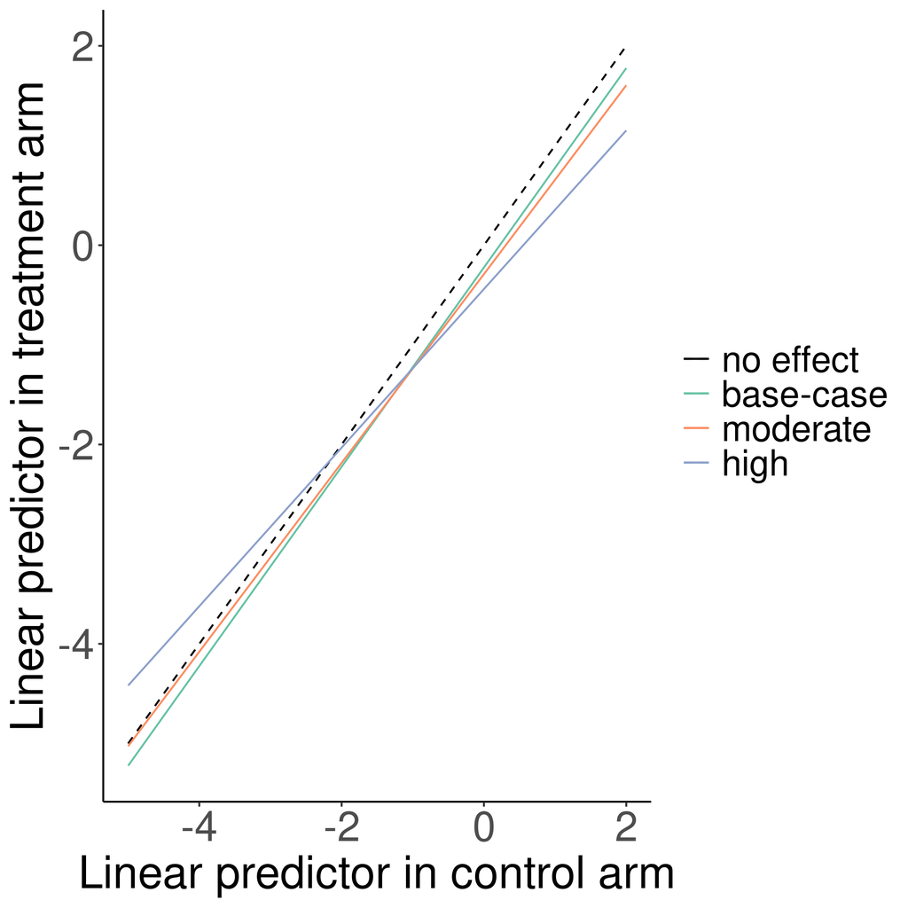

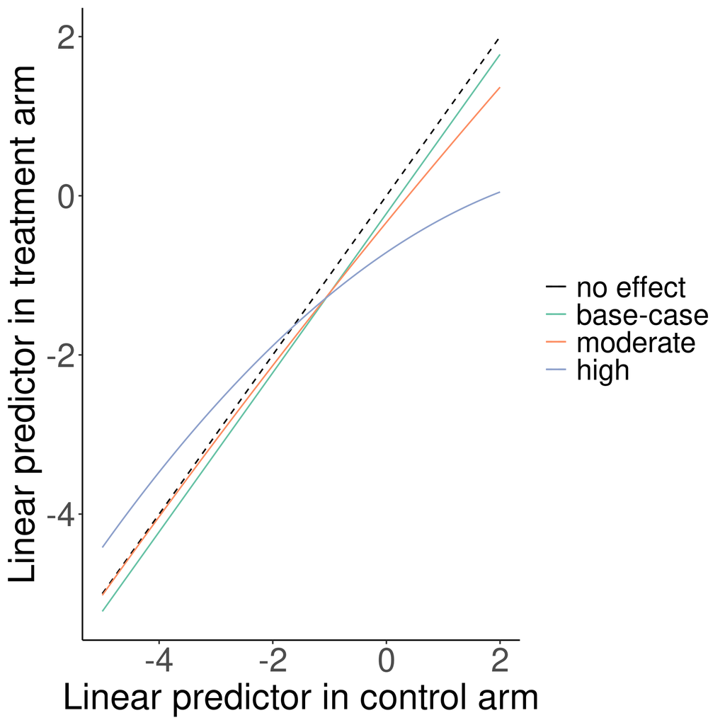

Linear and quadratic deviations from the base-case scenario of constant relative effect (OR=0.8)

## Setting

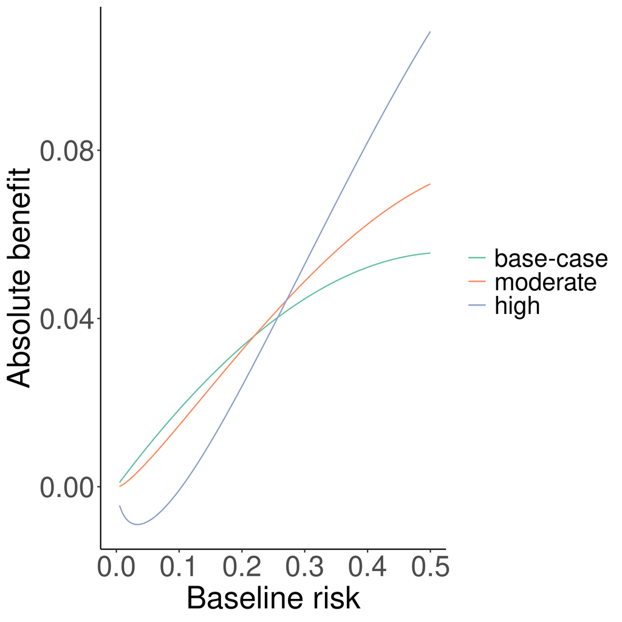

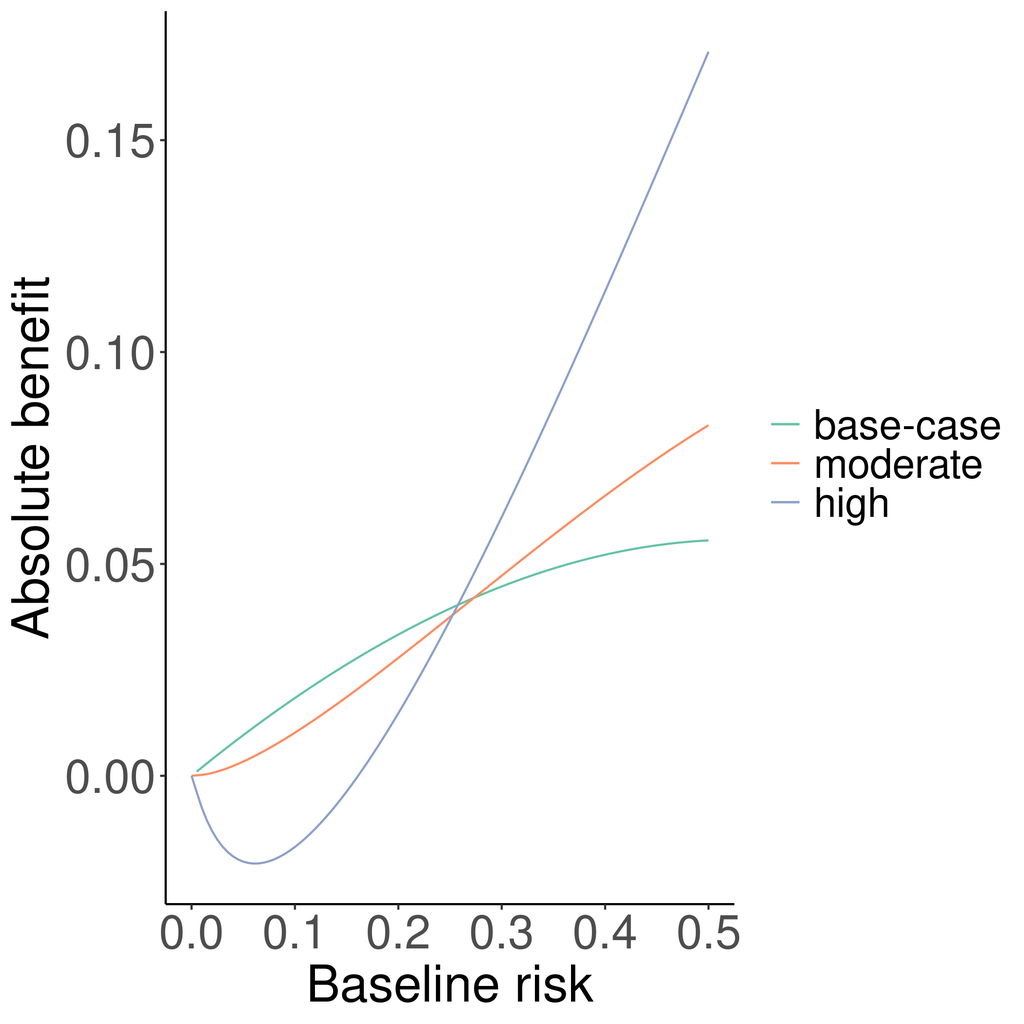

Linear and quadratic deviations from the base-case scenario of constant relative effect (OR=0.8)

## Setting

**Base-case scenario**

- Constant odds ratio: 0.8
- Sample size: 4250
- Outcome incidence, if left untreated: 20%
- Prediction model “true” AUC: 0.75

**Deviations**

- Sample size: 1064, 17000
- Overall treatment effect: 0.5, 1
- Prediction performance: 0.65, 0.85

## Setting

Finally, we consider 3 additional scenarios of interaction of individual covariates with treatment. These scenarios include a 4 weak interactions (\(\text{OR}_{t_x=1} / \text{OR}_{t_x=0}=0.82\)), 4 strong interactions (\(\text{OR}_{t_x=1} / \text{OR}_{t_x=0}=0.61\)), and 2 weak and 2 strong interactions.

## Methods

**Constant treatment effect** \[E\{y\:\vert\:x,t_x\} = P(y\:\vert\:x, t_x) = g(\beta_0+\beta_1x_1+\dots+\beta_8x_8+\gamma t_x)\] Absolute benefit is estimated from: \[\hat{f}_{\text{benefit}}(lp\:\vert\:x, \hat{\beta}) = g(lp) - g(lp+\hat{\gamma}) \]

## Methods

**Linear interaction** \[E\{y\:\vert\:x, t_x, \hat{\beta}\} = g\big(lp+(\delta_0+\delta_1lp)t_x\big)\]

Predict absolute benfit from: \[\hat{f}_{\text{benefit}}(lp\:\vert\:x, \hat{\beta}) = g(lp) - g\big(\delta_0+(1+\delta_1)lp\big)\]

## Methods

**Non-linear interaction** \[f_{\text{benefit}}(lp\:\vert\:x,\hat{\beta}) = \hat{f}_{\text{smooth}}(lp\:\vert\:x, \hat{\beta}, t_x=0) - \hat{f}_{\text{smooth}}(lp\:\vert\:x, \hat{\beta}, t_x=1)\] We consider three different approaches to smoothing:

- Loess
- Restricted cubic splines
- Local likelihood

## Demonstration

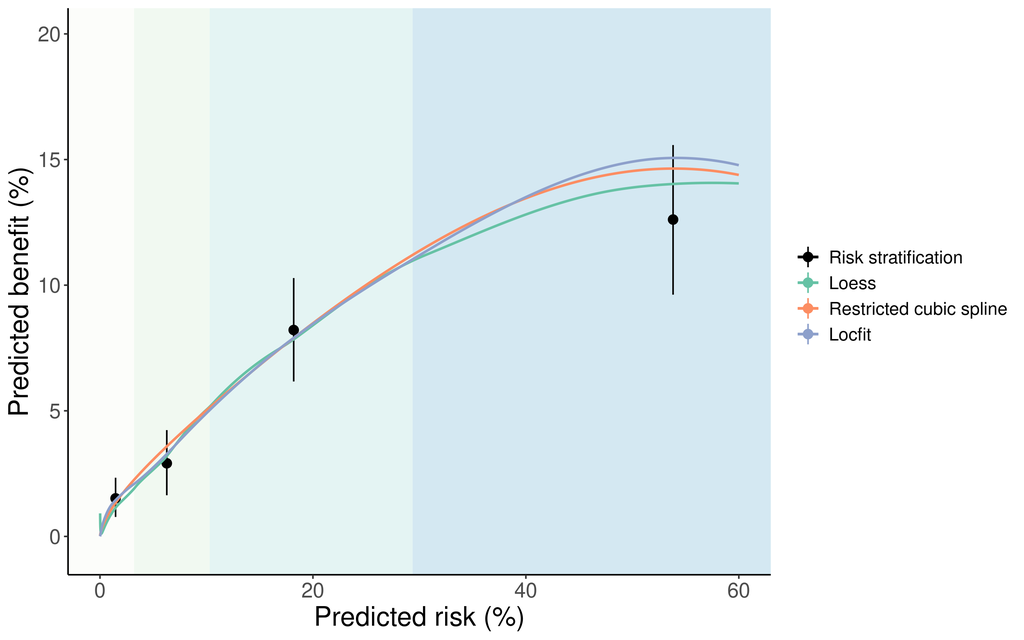

## Evaluation

**Root mean squared error**

Assuming that \(\tau(x)=E\{y\:\vert\:x, t_x=0\} - E\{y\:\vert\:x,t_x=1\}\) is the true benefit for each patient and \(\hat{\tau}(x)\) is the estimated benefit from a method under study, the ideal loss function to use for the considered methods would be the unobservable root mean squared error \(E\big\{(\hat{\tau} - \tau)^2\:\vert\:x\big\}\).

We will estimate the RMSE from \[\text{RMSE}=\frac{1}{n}\sum_{i=1}^n\big(\tau(x_i) - \hat{\tau}(x_i)\big)^2\]

## Evaluation

**C-for-benefit**

- Match patients on predicted benefit
- Use differences of observed outcomes within pairs as “observed benefit”
- Proceed with calculation of the concordance statistic

**Calibration for benefit**

- Match patients on predicted benefit
- Use differences of observed outcomes within pairs as “observed benefit”
- Fit smooth calibration curve
- Calculate the integrated calibration index

## Simulations

- Total of 66 scenarios
- Replicate each scenario 1000 times
- For each scenario, evaluations are made on a super-population of 500,000